# CSCI E-63C: Week 2 Problem Set

# Preface

One of the first steps in the analysis of a new dataset, often as part of data cleaning, typically involves generation of high level summaries, such as: how many observations, attributes, which ones are predictors and which ones are (could be?) outcomes, what are their ranges, distributions, percentages of missing values, how strongly correlated are the predictors among themselves and with the outcome(s), etc. It is usually at this stage when we develop our initial intuition about the level of difficulty of the problem and of the challenges presented by this particular dataset and therefore form our first set of ideas as to how to approach it. There are many multivariate methods under unsupervised learning umbrella that are extremely useful in this setting (that will be introduced later in the course), but first things first, and here we will start by loading few datasets into R and exploring their attributes in the form of univariate summaries and bivariate plots and contingency tables (where applicable).

For this problem set we will use several datasets available from [UCI machine learning repository](http://archive.ics.uci.edu/ml/datasets.html) that for convenience and as to not to depend on UCI ML repository availability have been also copied into this course website. Once you have downloaded them onto your computer, they can be loaded into R using function `read.table` with necessary options (of which most useful/relevant include: `sep` – defining field separator and `header` – instructing `read.table` to use fields in the first line as column headers). In principle, `read.table` can also use URL as a full path to the dataset, but here, to be able to work independently of network connection, we recommend that you download those datasets locally and provide `read.table` with appropriate paths to their local copies. The simplest thing is probably to copy them to the same directory where your .Rmd file is, in which case just the file name passed to `read.table` should suffice. As always, please remember, that `help(read.table)` (or, `?read.table` as a shorthand) will tell you quite a bit about this function and its parameters.

For those datasets that do not have column names included in their data files, it is often convenient to assign them explicitly. Please note that for some of these datasets categorical variables are encoded in the form of integer values, that by default R will interpret as continuous variables while the behavior of many R functions depends on the type of the input variables.

The code excerpts and their output presented below illustrate some of these most basic steps as applied to one of the datasets available from UCI. The homework problems follow after that – they will require you to apply similar kind of approaches to generate high levels summaries of few other UCI datasets.

```r
habDat <- read.table("haberman.data",sep=",")
colnames(habDat) <- c("age","year","nodes","surv")
summary(habDat$surv)
```

```
##    Min. 1st Qu.  Median    Mean 3rd Qu.    Max.
##   1.000   1.000   1.000   1.265   2.000   2.000
```

```r
habDat$surv <- c("yes","no")[habDat$surv]
summary(habDat$surv)
```

```
##    Length     Class      Mode
##       306 character character
```

```r
habDat$surv <- factor(habDat$surv)
summary(habDat$surv)
```

```
##  no yes
##  81 225
```

The following two examples below show generation of xy-scatterplots of age and node count for the patients in this dataset with color indicating their survival past 5 years using basic plotting capabilities in R as well as those provided by the package `ggplot2`.

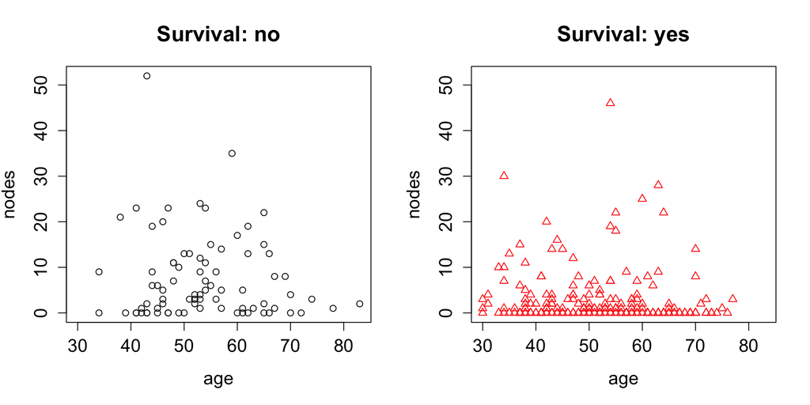

```r
oldPar <- par(mfrow=c(1:2),ps=16)
for ( iSurv in sort(unique(habDat$surv)) ) {
    plot(habDat[,c("age","nodes")],type="n",
        main=paste("Survival:",iSurv))
    iTmp <- (1:length(levels(habDat$surv)))[levels(habDat$surv)==iSurv]
    points(habDat[habDat$surv==iSurv,c("age","nodes")],col=iTmp,pch=iTmp)
}
```

```r
par(oldPar)
```

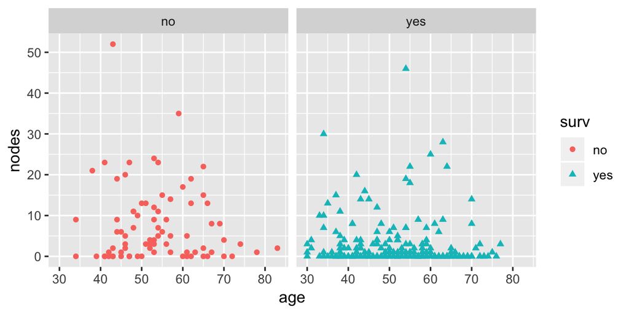

```r
ggplot(habDat,aes(x=age,y=nodes,colour=surv,shape=surv)) +
geom_point() + facet_wrap(~surv)
```

It seems that higher number of nodes might be associated with lower probability of survival. One attempt to quantify this relationship might involve testing relationship between indicators of survival and count of nodes exceeding arbitrarily chosen cutoffs (zero or 75th percentile in the example below). There is also substantial degree of overplotting due to integer values of node count and year that might, for instance, make it less apparent that not all patients with zero nodes survive if all of them were plotted in the same panel.

```r
habDat$nodes0 <- habDat$nodes==0
table(habDat[, c("surv","nodes0")])
```

```
##      nodes0
## surv  FALSE TRUE
##   no     62   19
##   yes   108  117
```

```r
habDat$nodes75 <- habDat$nodes>=quantile(habDat$nodes,probs=0.75)
table(habDat[, c("surv","nodes75")])
```

```
##      nodes75
## surv  FALSE TRUE
##   no     39   42
##   yes   178   47
```

Please feel free to model your solutions after the examples shown above, while exercising necessary judgement as to which attributes are best represented as continuous and which ones – as categorical, etc. The descriptions of homework problems provide some guidance as to what is expected, but leave some of those choices up to you. Making such calls is an integral part of any data analysis project and we will be working on advancing this skill throughout this course.

**Lastly – do ask questions! Piazza is the best for that**

# Banknote authentication (30 points)

This dataset presents an example of classification problem (authentic vs. counterfeit bank notes) using continuous predictors derived from image processing. More details about underlying data can be found in corresponding [dataset description](http://archive.ics.uci.edu/ml/datasets/banknote+authentication) at UCI ML website. To load data into R please use data file `data_banknote_authentication.txt` available at the course website as well as in UCI ML dataset repository.

Once the dataset in loaded into R, please name appropriately data set attributes, determine number of variables (explain which ones are predictors and which one is the outcome) and observations in the dataset (R functions such as `dim`, `nrow`, `ncol` could be useful for this), generate summary of the data using `summary` function in R and generate pairwise XY-scatterplots of each pair of continuous predictors indicating outcome using colour and/or shape of the symbols (you may find it convenient to use `pairs` plotting function). Describe your observations and discuss which of the variables are more likely to be informative with respect to discriminating forged bank notes from genuine.

Please comment on whether given the data at hand such problem appears to be an easy or hard one to solve. Try to guess using your best intuition, what could be an error in discriminating forged banknotes from genuine in this dataset: 50%, 20%, 10%, 5%, 2%, less than that? Later in the course we will work with this dataset again to actually develop such a classifier at which point you will get quantitative answer to this question, but for now, just from visual inspection of the scatterplots above, what do you think such an error could be? There is no wrong answer at this point, just try your best and make a note of it, so you can go back to it several weeks later. Also, please discuss some of the tradeoffs that might be associated with that. For instance, should one expect the cost of calling genuine note counterfeit to be the same as making the opposite call (allowing fake bills as authentic). Consider also anticipated frequency of these cases in the practical settings and how it could potentially interact with these costs.

```r
bankData <- read.table("data_banknote_authentication.txt",sep=",")
colnames(bankData) <- c(
  "imgVar",
  "imgSkew",
  "imgKurt",
  "imgEnt",
  "class"
)
```

```r
summary(bankData)
```

```
##      imgVar           imgSkew           imgKurt            imgEnt
##  Min.   :-7.0421   Min.   :-13.773   Min.   :-5.2861   Min.   :-8.5482
##  1st Qu.:-1.7730   1st Qu.: -1.708   1st Qu.:-1.5750   1st Qu.:-2.4135
##  Median : 0.4962   Median :  2.320   Median : 0.6166   Median :-0.5867
##  Mean   : 0.4337   Mean   :  1.922   Mean   : 1.3976   Mean   :-1.1917
##  3rd Qu.: 2.8215   3rd Qu.:  6.815   3rd Qu.: 3.1793   3rd Qu.: 0.3948
##  Max.   : 6.8248   Max.   : 12.952   Max.   :17.9274   Max.   : 2.4495
##      class
##  Min.   :0.0000
##  1st Qu.:0.0000
##  Median :0.0000
##  Mean   :0.4446
##  3rd Qu.:1.0000
##  Max.   :1.0000
```

```r
print(paste("There are", nrow(bankData), "observations in the dataset."))
```

```
## [1] "There are 1372 observations in the dataset."
```

It appears there are four predictors and one outcome, and there are 1372 observations in this dataset.

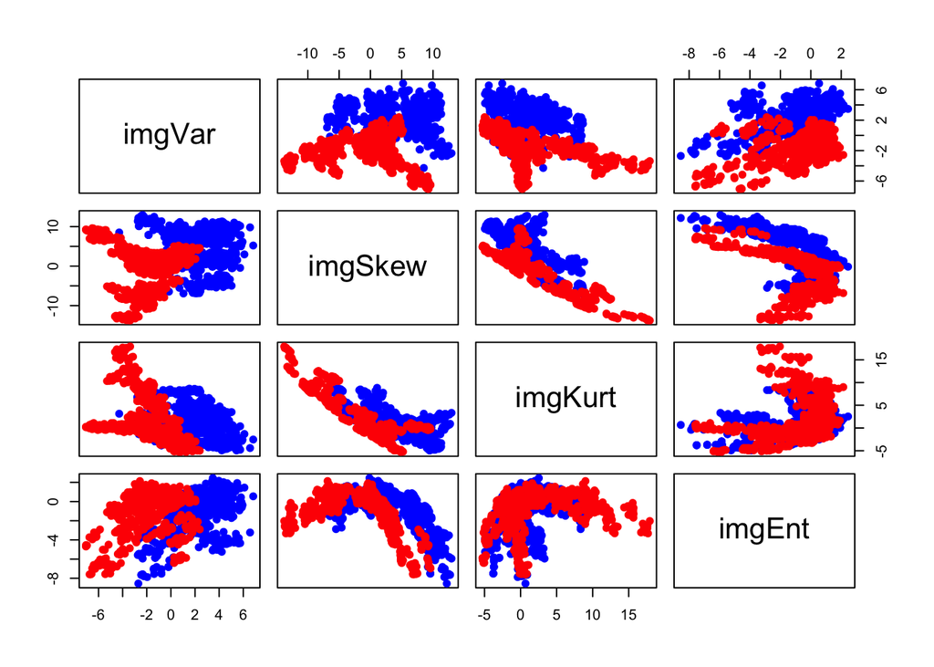

```r
colors <- c("blue", "red")[bankData$class + 1]
pairs(bankData[ 1:4 ], col=colors, pch=19)
```

Based on the seperation between the two classes in many of the pairs plots, it seems like the problem would not be too difficult. For example, the variance and skew plot shows fairly good seperation between the two. There is also decent seperation in variance / kurtosis and variance / skew. Of course, some pairs plots like kurtosis / entropy show essentially no seperation at all. I would guess a well-calibrated classifier would give 10% error or less.

The dataset itself is balanced, but clearly in the real world there are a vast number more genuine bills than counterfeit ones. That could have some effect on the data collection methods, and therefore on any prediction method developed.

# Abalone age (30 points)

This dataset presents an example of a regression problem – predicting mollusc age from measurements that are easier to obtain. More details about underlying data can be found in corresponding [dataset description](http://archive.ics.uci.edu/ml/datasets/Abalone). To load data into R please use file `abalone.data` available at the course website as well as at the UCI ML data repository.

Once the dataset in loaded into R, please name appropriately data set attributes, determine number of variables (explain which ones are predictors – categorical vs. continuous – and which one is the outcome) and observations in the dataset (R functions such as `dim`, `nrow`, `ncol` could be useful for this), generate summary of the data using `summary` function in R and generate pairwise XY-scatterplots of each pair of *continuous* attributes.

Describe your observations and discuss which attributes might be more useful for predicting snail age.

For **extra 5 points** for some of the continuous and categorical predictors generate boxplots rendering relationship between them.

```r
abalone <- read.table("abalone.data",sep=",")
colnames(abalone) <- c(
  "sex",
  "length",
  "diameter",
  "height",
  "whole_wt",
  "shucked_wt",
  "viscera_wt",
  "shell_wt",
  "rings"
)
```

```r
print(paste("Predictor columns:", ncol(abalone) - 1))
```

```
## [1] "Predictor columns: 8"
```

```r
print(paste("Observations:", nrow(abalone)))
```

```
## [1] "Observations: 4177"
```

```r
sapply(abalone, class)
```

```
##        sex     length   diameter     height   whole_wt shucked_wt
##   "factor"  "numeric"  "numeric"  "numeric"  "numeric"  "numeric"
## viscera_wt   shell_wt      rings
##  "numeric"  "numeric"  "integer"
```

```r
summary(abalone)
```

```
##  sex          length         diameter          height
##  F:1307   Min.   :0.075   Min.   :0.0550   Min.   :0.0000
##  I:1342   1st Qu.:0.450   1st Qu.:0.3500   1st Qu.:0.1150
##  M:1528   Median :0.545   Median :0.4250   Median :0.1400
##           Mean   :0.524   Mean   :0.4079   Mean   :0.1395
##           3rd Qu.:0.615   3rd Qu.:0.4800   3rd Qu.:0.1650
##           Max.   :0.815   Max.   :0.6500   Max.   :1.1300
##     whole_wt        shucked_wt       viscera_wt        shell_wt
##  Min.   :0.0020   Min.   :0.0010   Min.   :0.0005   Min.   :0.0015
##  1st Qu.:0.4415   1st Qu.:0.1860   1st Qu.:0.0935   1st Qu.:0.1300
##  Median :0.7995   Median :0.3360   Median :0.1710   Median :0.2340
##  Mean   :0.8287   Mean   :0.3594   Mean   :0.1806   Mean   :0.2388
##  3rd Qu.:1.1530   3rd Qu.:0.5020   3rd Qu.:0.2530   3rd Qu.:0.3290
##  Max.   :2.8255   Max.   :1.4880   Max.   :0.7600   Max.   :1.0050
##      rings
##  Min.   : 1.000
##  1st Qu.: 8.000
##  Median : 9.000
##  Mean   : 9.934
##  3rd Qu.:11.000
##  Max.   :29.000
```

Based on the above information, there are 8 predictor columns and 4177 observations. The outcome is the number of rings. Most of the data is continuous, with the exception of sex and the target variable, rings, which is discrete.

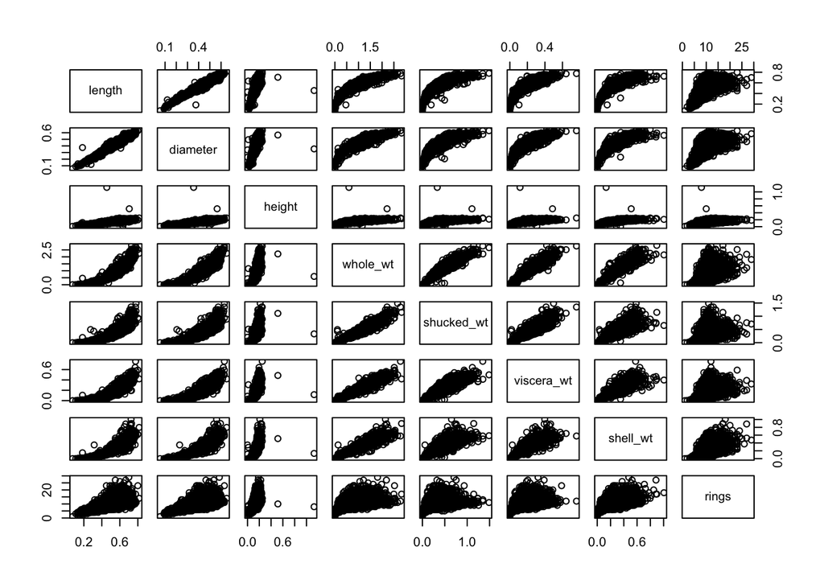

```r
abaloneContinuousCols <- c(
  "length",
  "diameter",
  "height",
  "whole_wt",
  "shucked_wt",
  "viscera_wt",
  "shell_wt"
)
pairs(abalone[, c(abaloneContinuousCols, "rings")])
```

It appears that quite a lot of these parameters are correlated. Particularly the size predictors are all correlated, and the weights are fairly well correlated with each other. As far as predictive power, they all look fairly similar. Maybe the shell weight looks a little tighter than other predictors, but not by much. I’m guessing picking a single size parameter and a single weight parameter would be not much less predictive than using all size and weight parameters to predict the number of rings.

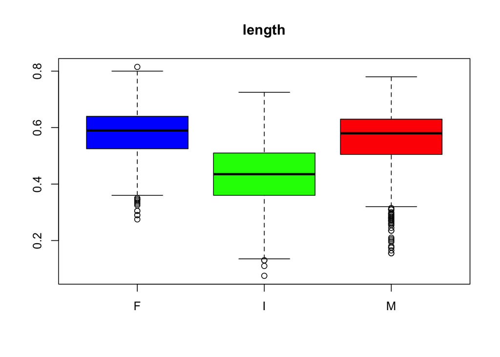

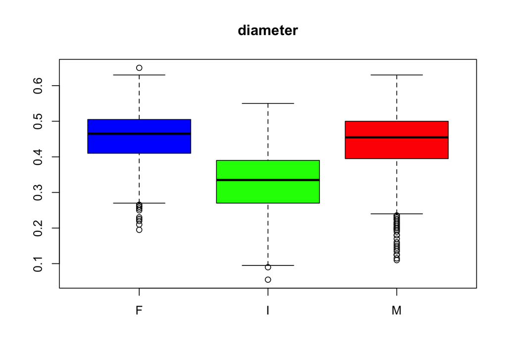

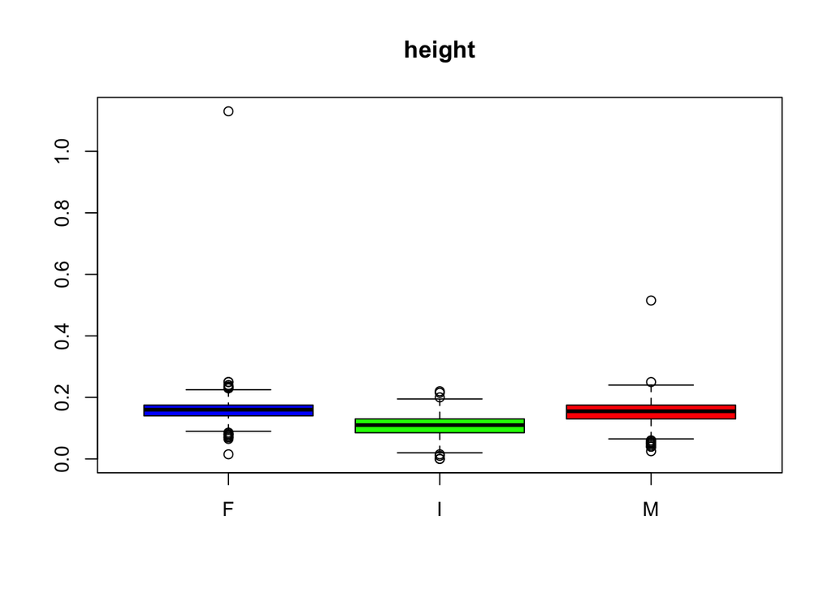

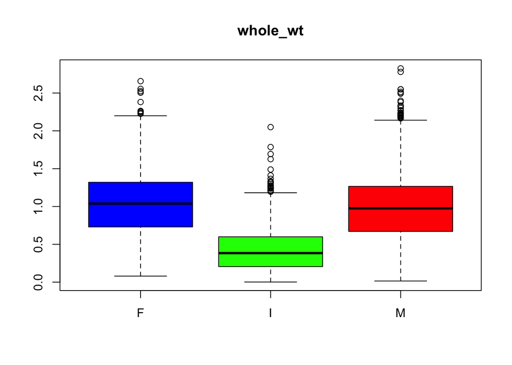

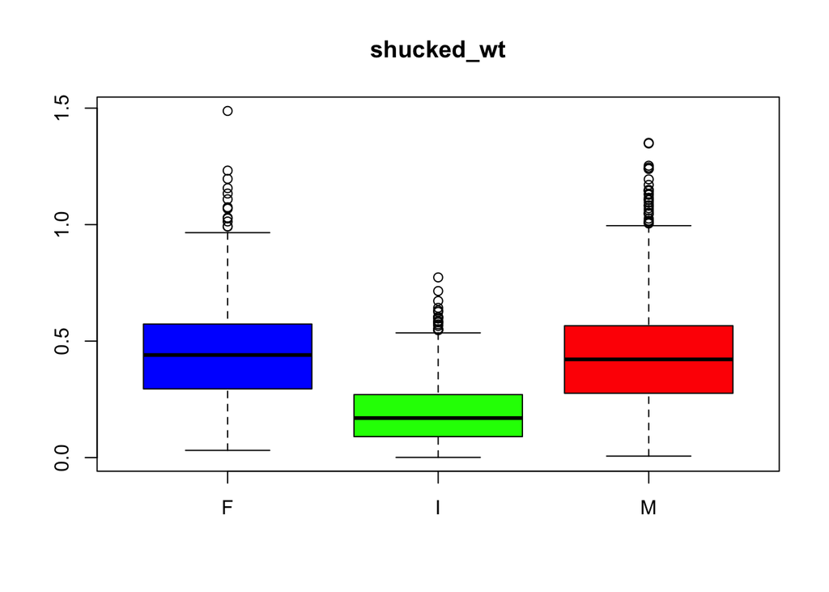

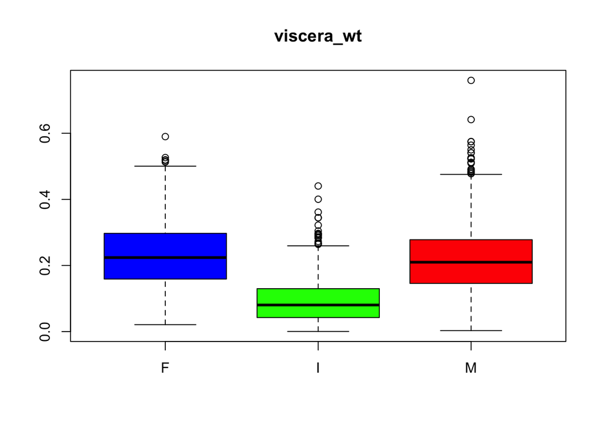

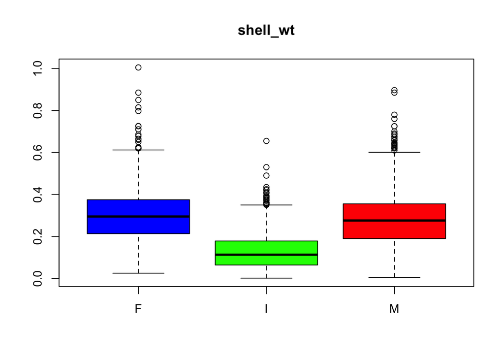

```r
for (contVar in abaloneContinuousCols) {
  boxplot(abalone[,contVar] ~ abalone$sex, col=c("blue", "green", "red"), main=contVar)
}
```

It appears the F and M sexes are about the same size and weight. The females are slightly larger but not by much. In a somewhat obvious sense, infants are much smaller than males and females.

# Tibbles (extra 5 points)

Fluency in R (as any other programming language) involves ability to look up, understand and put to use as necessary functionality that has not been explored before. One of relatively recent additions to R are so-called tibbles that can be seen as [“modern take on data frames”](https://cran.r-project.org/web/packages/tibble/vignettes/tibble.html). To earn extra points for this week problem set, please look up tibble use and constrast their behavior to that of conventional data frame using one of the datasets you have already created above. To earn all points available your solution must include more than one example of substantive difference (i.e. same kind of difference illustrated by two datasets counts as one). Please also comment on why use of tibbles may result in more robust code.